# HW7 - Statistical Inference

Madhu Peduri

July 4, 2021

### 1.Analyzing Data with a Categorical Outcome.

#### 1.1 (a) Enter the data into R in an expanded form

```r
cat <- c(rep("Yes", 630), rep("No", 670))
vec <- factor(cat)
binge <- data.frame(vec)
names(binge) <- c("BingeDrink")
head(binge)
```

|  | BingeDrink |
| --- | --- |
| 1 | Yes |
| 2 | Yes |
| 3 | Yes |
| 4 | Yes |
| 5 | Yes |
| 6 | Yes |

#### 1.1 (b) Frequency charts

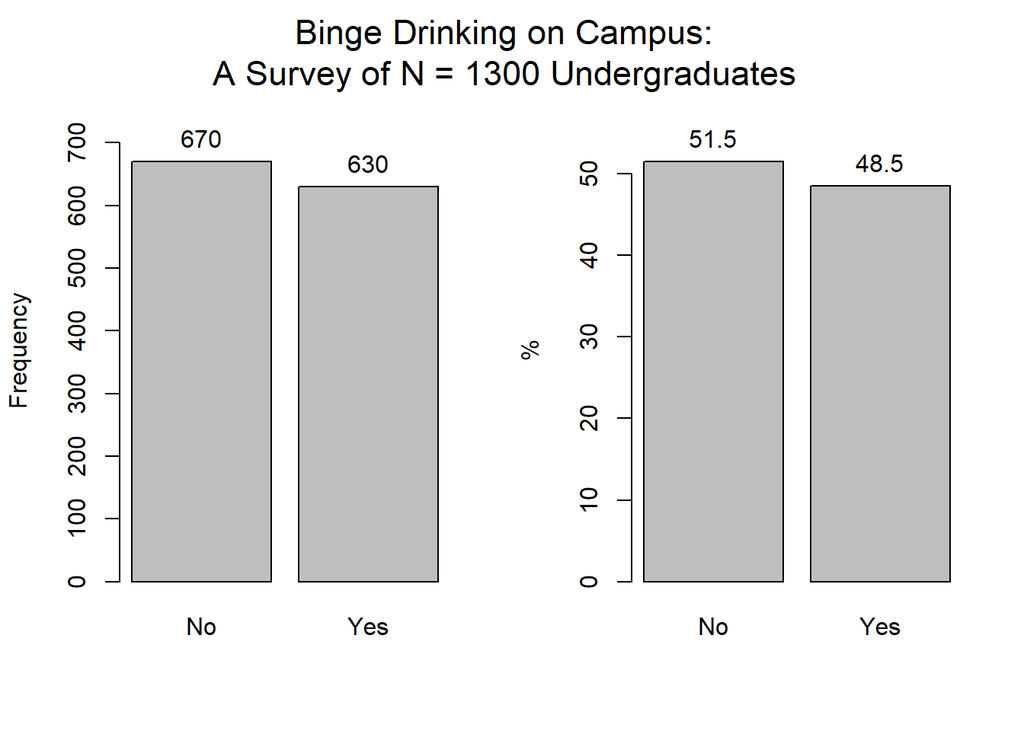

```r
par(mfrow = c(1, 2))
t1 <- tab1(binge, main = "")
t2 <- tab1(binge, bar.values = "percent", main = "")
mtext("Binge Drinking on Campus:", side = 3, line = 2.4, at = -0.8,
    cex = 1.4)
mtext("A Survey of N = 1300 Undergraduates", line = 1, side = 3,
    at = -0.8, cex = 1.4)
```

#### 1.2 (a) Prop & Binomial test

```r
prop.test(x = length(binge$BingeDrink[binge$BingeDrink == "Yes"]),
    n = length(binge$BingeDrink), p = 0.5)
```

```
##
##  1-sample proportions test with continuity correction
##
## data:  length(binge$BingeDrink[binge$BingeDrink == "Yes"]) out of length(binge$BingeDrink), null probability 0.5
## X-squared = 1, df = 1, p-value = 0.3
## alternative hypothesis: true p is not equal to 0.5
## 95 percent confidence interval:
##  0.457 0.512
## sample estimates:
##     p
## 0.485
```

```r
binom.test(x = length(binge$BingeDrink[binge$BingeDrink == "Yes"]),
    n = length(binge$BingeDrink), p = 0.5)
```

```
##
##  Exact binomial test
##
## data:  length(binge$BingeDrink[binge$BingeDrink == "Yes"]) and length(binge$BingeDrink)
## number of successes = 630, number of trials = 1300, p-value = 0.3
## alternative hypothesis: true probability of success is not equal to 0.5
## 95 percent confidence interval:
##  0.457 0.512
## sample estimates:
## probability of success
##                  0.485
```

#### 1.2 (b)(i) Chi-square goodness

```r
# When probability of happeining Yes and No are equal to
# 1/2
prob <- c(length(binge$BingeDrink[binge$BingeDrink == "Yes"]),
    length(binge$BingeDrink[binge$BingeDrink == "No"]))
chisq.test(prob, p = c(1/2, 1/2))
```

```
##
##  Chi-squared test for given probabilities
##
## data:  prob
## X-squared = 1, df = 1, p-value = 0.3
```

```r
chisq.test(prob, p = c(1/3, 2/3))
```

```
##
##  Chi-squared test for given probabilities
##
## data:  prob
## X-squared = 134, df = 1, p-value <2e-16
```

#### Observations:

- The chi-square goodness of fit test is used to compare the observed distribution to an expected distribution, in a situation where we have two or more categories in a discrete data. In other words, it compares multiple observed proportions to expected probabilities.
- For the hypothesis $H_{0}:p_{1} = p_{2}$, with same probability for both categorical values, we have p-value = 0.3 (> 0.05). This says that, observed proportions are not different from the expected proportions.
- For the hypothesis $H_{1}:p_{1} \neq p_{2}$, with different probability for both categorical values, we have p-value very less. This says that, observed proportions are different from the expected proportions.

#### 1.2 (b)(ii)

```r
pi = 0.247
chisq.test(prob, p = c(pi, 1 - pi))
```

```
##
##  Chi-squared test for given probabilities
##
## data:  prob
## X-squared = 395, df = 1, p-value <2e-16
```

#### Observations:

- If we use the proportion = 0.247 by NSDUH as expected hypothesis, we are getting a less p-value. We can say this, our actual proportion do not comply with expected hypothesis.
- We can see 0.247*1300 = 321.1 (< 630) which is less than the actual number of successes.

#### 1.2 (c)

```r
prop.test(x = 630, n = 1300, p = 0.247, alternative = "g")
```

```
##
##  1-sample proportions test with continuity correction
##
## data:  630 out of 1300, null probability 0.247
## X-squared = 393, df = 1, p-value <2e-16
## alternative hypothesis: true p is greater than 0.247
## 95 percent confidence interval:
##  0.461 1.000
## sample estimates:
##     p
## 0.485
```

```r
binom.test(x = 630, n = 1300, p = 0.247, alternative = "g")
```

```
##
##  Exact binomial test
##
## data:  630 and 1300
## number of successes = 630, number of trials = 1300, p-value <2e-16
## alternative hypothesis: true probability of success is greater than 0.247
## 95 percent confidence interval:
##  0.461 1.000
## sample estimates:
## probability of success
##                  0.485
```

#### Observations:

- We can see in both the cases we have p-value is less.
- If we have proportion = 0.5 (>0.247), we have p-value that is sufficient which can be equivalent to hypothesis.

#### 1.3(a) Read Sales Data

```r
sales <- read.csv("sales.csv")
tabs <- xtabs(~Region + Sport, data = sales)
tabs
```

```
##       Sport
## Region  A  S  W
##      A  9  6 22
##      B 13 31  7
##      C  7 15  0
##      D 14 13 13
```

#### 1.3(b) Mosaic Plot

```r
ptab <- prop.table(tabs)
ptab
```

```
##       Sport
## Region      A      S      W
##      A 0.0600 0.0400 0.1467
##      B 0.0867 0.2067 0.0467
##      C 0.0467 0.1000 0.0000
##      D 0.0933 0.0867 0.0867
```

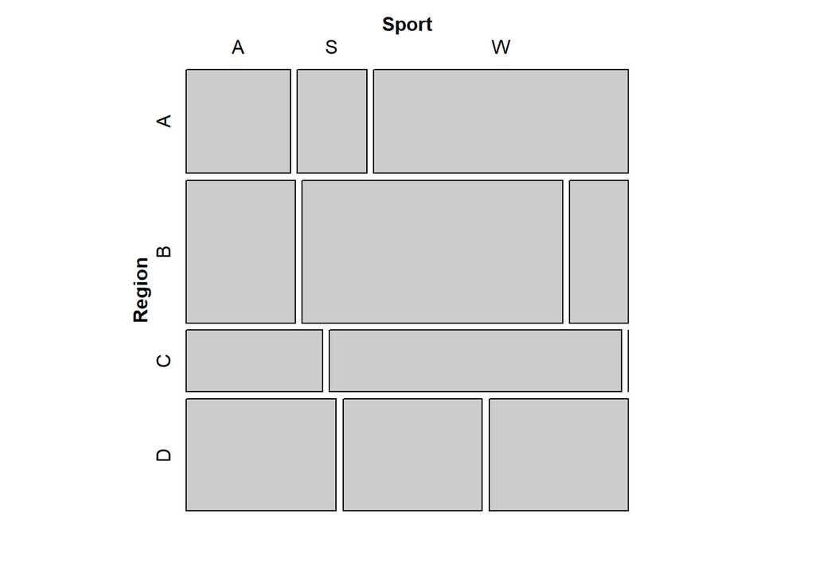

```r
mosaic(ptab, zero_size = 0)
```

#### Observations:

- We can observe that Mosaic plot shows the equivalent densities.
- We can see that, Region B has highes sales for the Summer sport gear.

#### 1.3(c) Chi-square test of independence

```r
chisq.test(tabs)
```

```
##
##  Pearson's Chi-squared test
##
## data:  tabs
## X-squared = 38, df = 6, p-value = 9e-07
```

### 2. Analysis of Continuous Outcome Data

#### 2.1(a) One-Sample Tests

```r
car <- c(19, 26, 24, 21, 24, 23, 26, 24, 23, 20, 21, 24, 18,
    21, 20, 23, 24, 26, 25, 19, 24, 23, 27, 24, 26, 25, 20, 21,
    19, 23)
ttest <- t.test(car, mu = 25)
sprintf("p-value of t-test: %.10f", ttest$p.value)
```

```
## [1] "p-value of t-test: 0.0000343022"
```

```r
sprintf("Mean of the sample: %.2f", mean(car))
```

```
## [1] "Mean of the sample: 22.77"
```

```r
sprintf("Standard deviation of the sample: %.2f", sd(car))
```

```
## [1] "Standard deviation of the sample: 2.50"
```

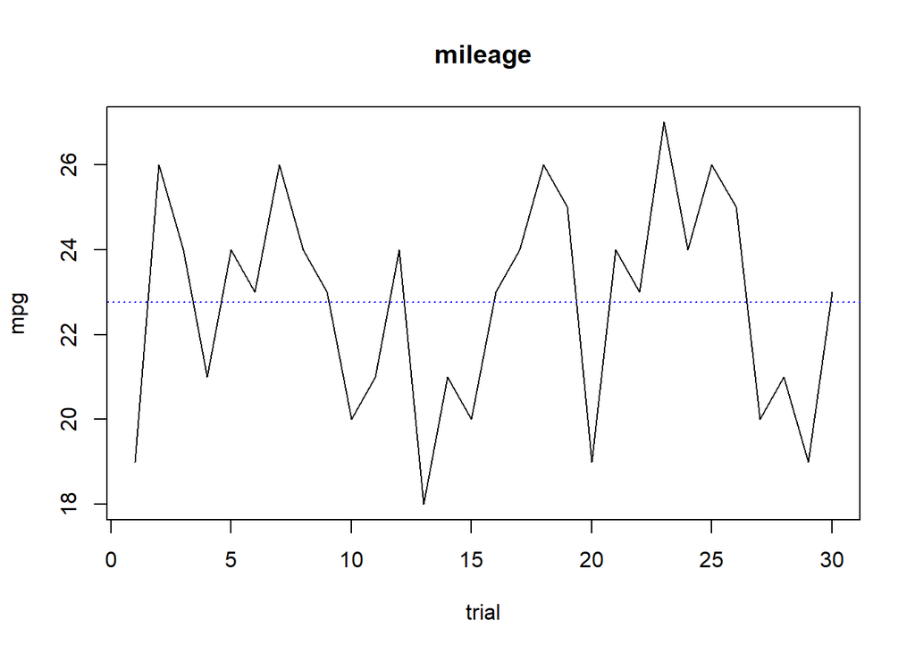

```r
plot(car, type = "l", xlab = "trial", ylab = "mpg", main = "mileage")
par(new = TRUE)
abline(h = mean(car), col = "blue", lty = 3)
```

#### Observations:

- We can see p-value of our t-test is less (inferior) to the significant value 0.05. This suggest that null hypothesis is incorrect and the hypothesis $H_{1}: \mu \neq 25$ is correct.

#### 2.1(b) Shaprio test

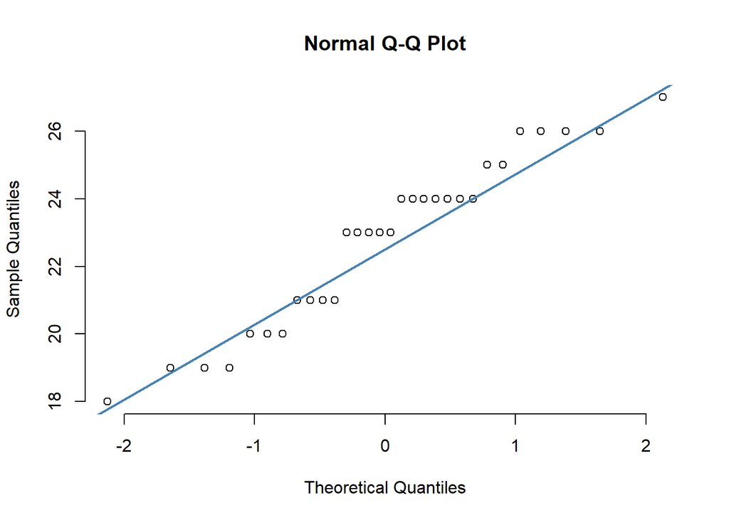

```r
qqnorm(car, pch = 1, frame = FALSE)
qqline(car, col = "steelblue", lwd = 2)
```

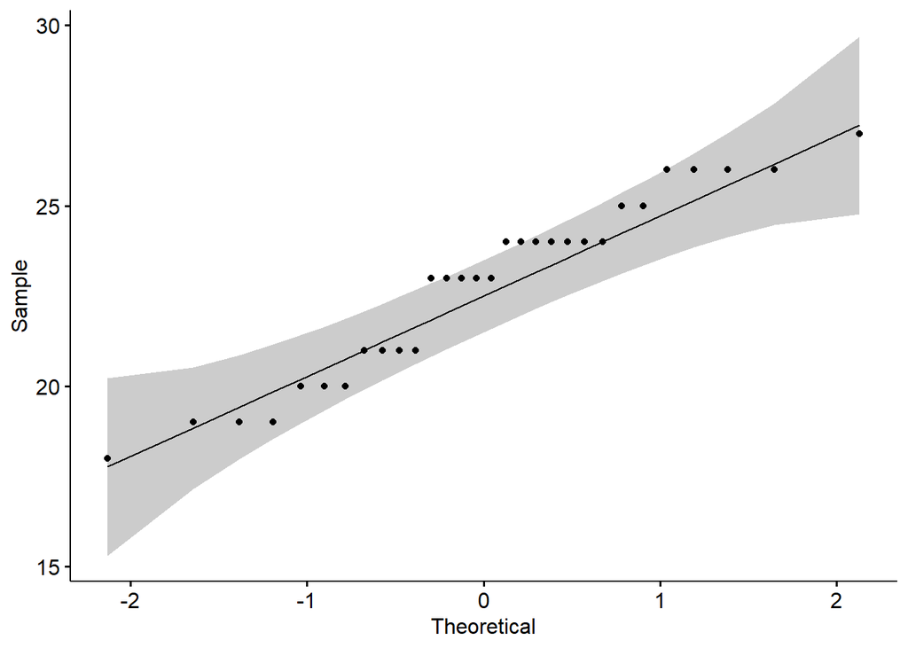

```r
ggqqplot(car)
```

```r
shapirotest <- shapiro.test(car)
sprintf("P-value of Shapiro normality test:%.4f", shapirotest$p.value)
```

```
## [1] "P-value of Shapiro normality test:0.0928"
```

#### Observations:

- From qqplots, we can see the sample quantiles follow a straight line and fall with in the range.
- The p-value of shapiro.test is 0.09 which is greater than significant value 0.05 suggests that our data follow normal distribution.

#### 2.1(c) t - test

```r
ttest <- t.test(car, alternative = "less", mu = 25)
ttest
```

```
##
##  One Sample t-test
##
## data:  car
## t = -5, df = 29, p-value = 2e-05
## alternative hypothesis: true mean is less than 25
## 95 percent confidence interval:
##  -Inf 23.5
## sample estimates:
## mean of x
##      22.8
```

```r
sprintf("P-value of t-test test:%.5f", ttest$p.value)
```

```
## [1] "P-value of t-test test:0.00002"
```

### 2.2(a) Dependent Samples Tests

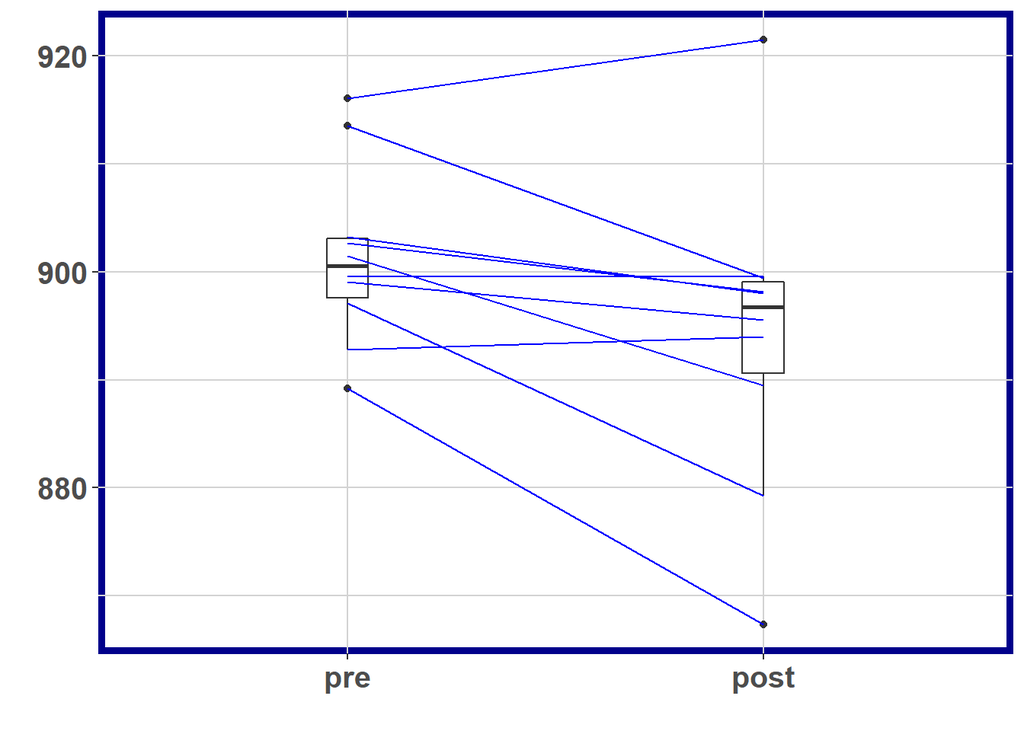

```r
id <- c(1:10)
pre <- c(899.63, 913.51, 897.05, 889.18, 903.2, 916.06, 899.08,
    892.75, 901.47, 902.63)
post <- c(899.53, 899.38, 879.25, 867.35, 897.97, 921.42, 895.52,
    893.95, 889.44, 898.14)
datap <- data.frame(cbind(id, pre, post))
paired.plotProfiles(datap, "pre", "post") + geom_line(color = "blue") +
    theme(panel.background = element_rect(fill = "white", colour = "dark blue",
        size = 3), axis.text.x = element_text(size = 15, face = "bold"),
        axis.text.y = element_text(size = 15, face = "bold"),
        panel.grid.major = element_line(colour = "light gray",
            size = 0.4), panel.grid.minor = element_line(colour = "light gray",
            size = 0.4))
```

### 2.2(b) Dependent Samples Tests

#### (i) Box plots

```r
sprintf("Pre-swim time - Mean:%.2f and Standard deviation:%.2f",
    mean(datap$pre), sd(datap$pre))
```

```
## [1] "Pre-swim time - Mean:901.46 and Standard deviation:8.29"
```

```r
sprintf("Post-swim time - Mean:%.2f and Standard deviation:%.2f",
    mean(datap$post), sd(datap$post))
```

```
## [1] "Post-swim time - Mean:894.20 and Standard deviation:14.12"
```

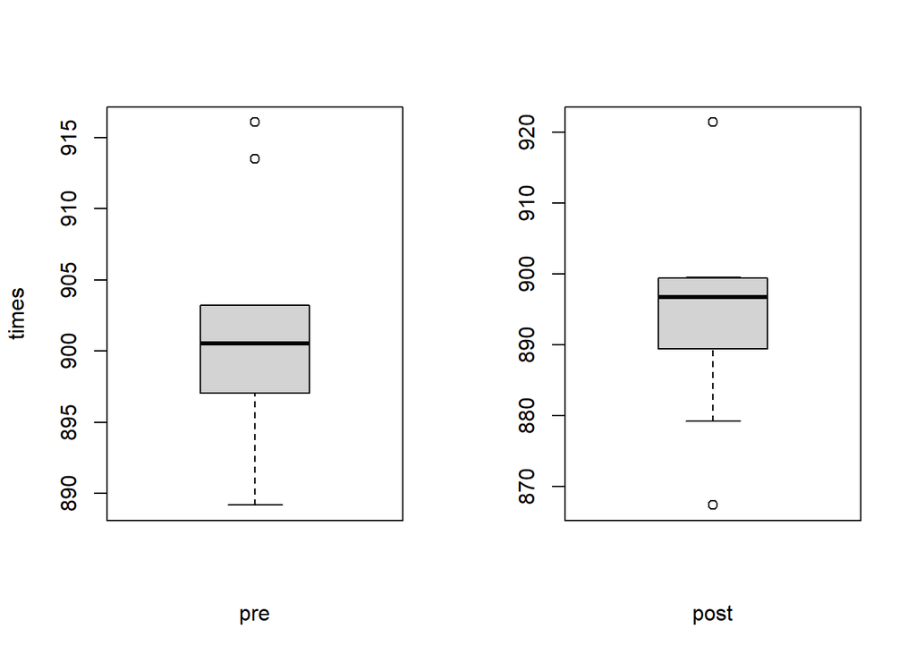

```r
par(mfrow = c(1, 2))
boxplot(x = datap$pre, xlab = "pre", ylab = "times")
boxplot(x = datap$post, xlab = "post")
```

#### (ii) Box plots

```r
paired_dif <- datap$pre - datap$post
sprintf("Paired differences - Mean:%.2f and Standard deviation:%.2f",
    mean(paired_dif), sd(paired_dif))
```

```
## [1] "Paired differences - Mean:7.26 and Standard deviation:8.82"
```

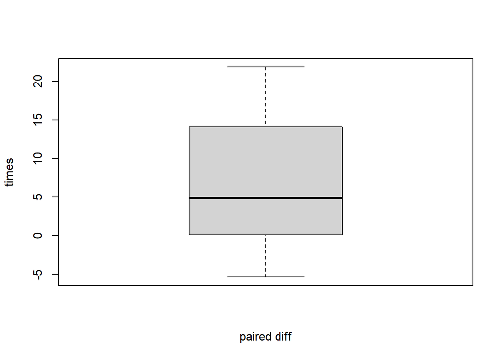

```r
boxplot(x = paired_dif, xlab = "paired diff", ylab = "times")
```

#### (iii) Normality test

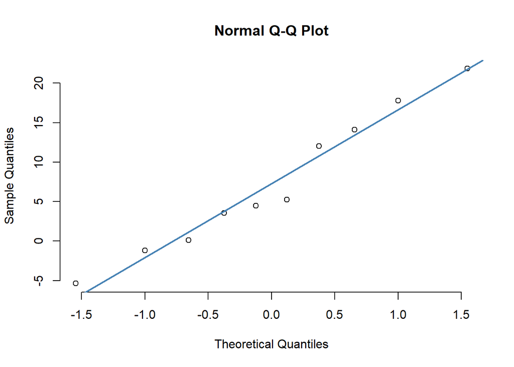

```r
qqnorm(paired_dif, pch = 1, frame = FALSE)
qqline(paired_dif, col = "steelblue", lwd = 2)
```

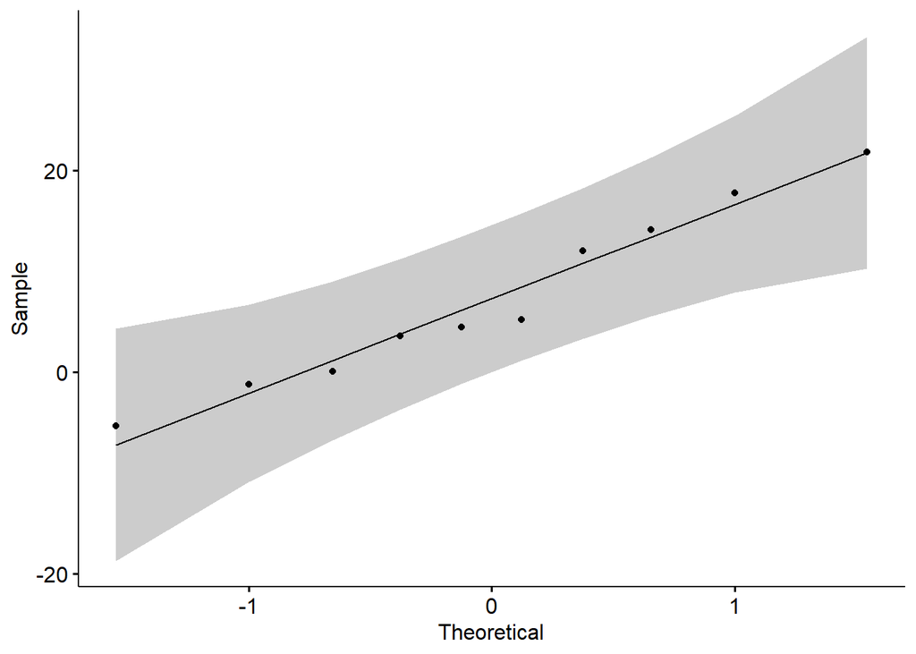

```r
ggqqplot(paired_dif)
```

```r
shapirotest <- shapiro.test(paired_dif)
sprintf("P-value of Shapiro normality test:%.4f", shapirotest$p.value)
```

```
## [1] "P-value of Shapiro normality test:0.7748"
```

#### Observation

- From the plots and shapiro test’s p-value = 0.78 indicates the nature of normality in paired differences

#### (iii) t - test

```r
datap$diff <- pre - post
t.test(pre, post, paired = TRUE, alternative = "greater")
```

```
##
##  Paired t-test
##
## data:  pre and post
## t = 3, df = 9, p-value = 0.01
## alternative hypothesis: true difference in means is greater than 0
## 95 percent confidence interval:
##  2.15  Inf
## sample estimates:
## mean of the differences
##                    7.26
```

```r
t.test(datap$diff, alternative = "greater", mu = 0)
```

```
##
##  One Sample t-test
##
## data:  datap$diff
## t = 3, df = 9, p-value = 0.01
## alternative hypothesis: true mean is greater than 0
## 95 percent confidence interval:
##  2.15  Inf
## sample estimates:
## mean of x
##      7.26
```

### 2.3 Wilcoxon Signed-Rank Test

```r
wilcox.test(datap$diff, alternative = "greater", mu = 0)
```

```
##
##  Wilcoxon signed rank exact test
##
## data:  datap$diff
## V = 47, p-value = 0.02
## alternative hypothesis: true location is greater than 0
```

## Document Information.

All of the statistical analyses in this document will be performed using R version 4.1.0 (2021-05-18). R packages used will be maintained using the [packrat](http://rstudio.github.io/packrat/) dependency management system.